# IODS course project

Annina Haverinen

# About the project

This course “IODS-Introduction to Open Data Science” is organized by the Doctoral School of Social Sciences and Centre for Research Methods, University of Helsinki. The theme of the course is open data, open science and data science. The aim of this course is to understand the concepts of open data and open science and learn how to use some of the open tools available (=data science). Students will learn to analyze and visualize data with sophisticated statistical methods with these open access tools and get familiar with the concept of reproduciable science.

Link to my GitHub repository: https://github.com/anninahaverinen/IODS-project

# Regression and model validation

Annina Haverinen, 7.11.2018 IODS-Project, Excercise 2

Getting started: Reading the data “learning2014” from local disk, the original data has been wrangled.

The learning2014 is a subset of a data from a study investigating the realationship between learning approaches and student achievements. The data learning2014 consists of 7 variables: gender (F/M), age, exam points, global attitude towards statistics, questions on surface learning, deep learning and strategic learning.There are 166 observations in this dataset representing 166 students.

```r
learning2014<-read.table("/Users/Annina/Documents/GitHub/IODS-project/Data/learning2014.txt")
```

Looking at the dimensions,structure and first observations of the data.

```r
dim(learning2014) # gives the dimensions of the dataset: 166 observations of 7 variables.
```

```
## [1] 166   7
```

```r
str(learning2014) # gives the names of the variables, type of variable (factorial with number of levels, numeric or integer) and the first observations
```

```
## 'data.frame':    166 obs. of  7 variables:
##  $ gender  : Factor w/ 2 levels "F","M": 1 2 1 2 2 1 2 1 2 1 ...
##  $ Age     : int  53 55 49 53 49 38 50 37 37 42 ...
##  $ Points  : int  25 12 24 10 22 21 21 31 24 26 ...
##  $ Attitude: int  37 31 25 35 37 38 35 29 38 21 ...
##  $ surf    : num  2.64 3.09 2.18 2.27 2.82 ...
##  $ deep    : num  3.58 2.92 3.5 3.5 3.67 ...
##  $ stra    : num  3.38 2.75 3.62 3.12 3.62 ...
```

Next a summary of the variables:

```r
summary(learning2014)
```

```
##  gender       Age            Points         Attitude          surf
##  F:110   Min.   :17.00   Min.   : 7.00   Min.   :14.00   Min.   :1.545
##  M: 56   1st Qu.:21.00   1st Qu.:19.00   1st Qu.:26.00   1st Qu.:2.455
##          Median :22.00   Median :23.00   Median :32.00   Median :2.818
##          Mean   :25.51   Mean   :22.72   Mean   :31.43   Mean   :2.783
##          3rd Qu.:27.00   3rd Qu.:27.75   3rd Qu.:37.00   3rd Qu.:3.091
##          Max.   :55.00   Max.   :33.00   Max.   :50.00   Max.   :4.273
##       deep            stra
##  Min.   :1.583   Min.   :1.250
##  1st Qu.:3.333   1st Qu.:2.625
##  Median :3.667   Median :3.188
##  Mean   :3.680   Mean   :3.121
##  3rd Qu.:4.083   3rd Qu.:3.625
##  Max.   :4.917   Max.   :5.000
```

From the summary we can see descriptive information of the variables. For factoral variables the quantity of the observations/level is given and for numeric variables the min-max values, 1st and 3rd quantile, mean and median. From this we can get an overview of the distribiution of the data/variable. From the summary it can be seen that “age” is skewed but the other variables quite normally distributed (normal distribiuton: mean almost equal to the median, quntiles symmetrical around mean, min-max symmetrical).

To get an idea over the possible relationships between the variables in the data we plot them in a plot matrix.

```r
library(ggplot2) #installed for graphics
library(GGally) #installed for graphics
```

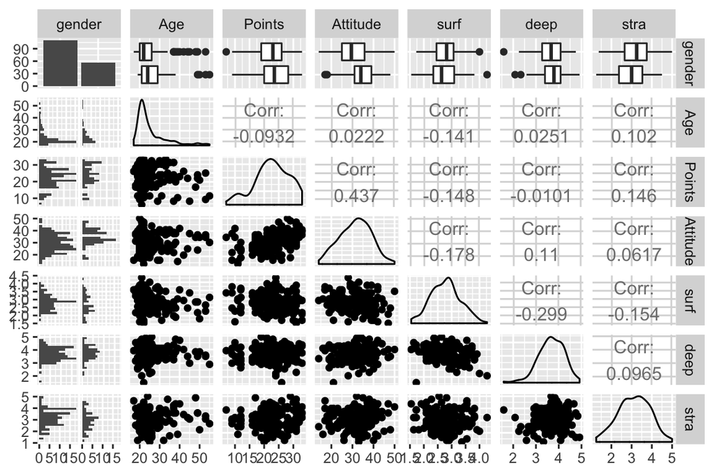

```r
ggpairs(learning2014, lower = list(combo = wrap("facethist", bins = 20))) # plot matrix of the data
```

The plot matrix gives us scatter plots of all possible combinations of the variables in the data fram. The matrix also gives correlation coefficients for the combinations and density lines for estimation of distribition. We can visually interpret the distribution of the variables, in this case the distribiutions are more or less normal for the other variables than “age”. Below a correlation matrix.

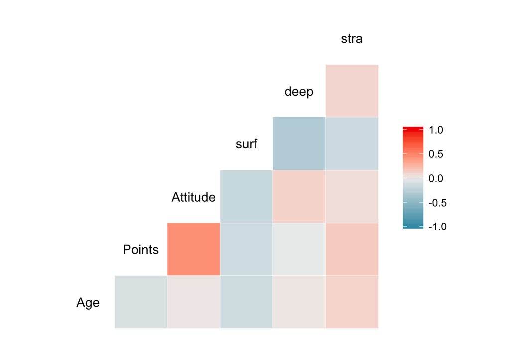

```r
p2<- ggcorr(learning2014 [-1]) # plots a correlation matrix, helps to visualize the correlated variables in the data set
p2
```

From these plots we can see that see that the “Attitude”-“Points” interaction has the highest correlation coefficient. We see that “Attitude” and “stra” are positively correlated with “Points” and that “deep” is slightly negatively correlated with “Points”.

In this multiple regression model (named LM1) I therfore include “Attitude”, “stra” and “deep” (3 variables required in the excercise) as explanatory variables to “Points”. In the next model (LM2) I include only “Attitude” and “stra”, these two being positvely correlated to “Points”. The last model (LM3) is a simple linear regression model with only one explanatory variable, “Attitude”.

```r
LM1<-lm(Points~Attitude+stra+deep, data=learning2014)
LM1
```

```
##
## Call:
## lm(formula = Points ~ Attitude + stra + deep, data = learning2014)
##
## Coefficients:
## (Intercept)     Attitude         stra         deep
##     11.3915       0.3525       0.9621      -0.7492
```

```r
summary(LM1) #metrics indicating the quality of the model fit
```

```
##
## Call:
## lm(formula = Points ~ Attitude + stra + deep, data = learning2014)
##
## Residuals:
##      Min       1Q   Median       3Q      Max
## -17.5239  -3.4276   0.5474   3.8220  11.5112
##
## Coefficients:
##             Estimate Std. Error t value Pr(>|t|)
## (Intercept) 11.39145    3.40775   3.343  0.00103 **
## Attitude     0.35254    0.05683   6.203 4.44e-09 ***
## stra         0.96208    0.53668   1.793  0.07489 .
## deep        -0.74920    0.75066  -0.998  0.31974
## ---
## Signif. codes:  0 '***' 0.001 '**' 0.01 '*' 0.05 '.' 0.1 ' ' 1
##
## Residual standard error: 5.289 on 162 degrees of freedom
## Multiple R-squared:  0.2097, Adjusted R-squared:  0.195
## F-statistic: 14.33 on 3 and 162 DF,  p-value: 2.521e-08
```

```r
confint(LM1) # confidence intervalls of the coefficient estimate, from this we can also tell if the coeffiecent estimates are significant in our model.
```

```
##                   2.5 %     97.5 %
## (Intercept)  4.66211614 18.1207860
## Attitude     0.24030902  0.4647614
## stra        -0.09769802  2.0218634
## deep        -2.23153872  0.7331395
```

Interpretation of the multiple linear regression model LM1:“Attitude”,“stra” and “deep” as explanatory variables for “Points”.

Residuals: (=how far from the regression line the observations are) shows how well data fits the model. The residual median should be close to mean (mean =0), and residuals should be normally distribiuted.

The Coefficient estimates are values of the slope calculated by the model regression. Signifcance levels for the coefficients estimates for the variables of the model are given with symbols and we see that the coefficient estimate is significant (*** = p = 0 ) for “Attitude”" and (“.” p= 0.05)" for “stra”. The estimate coefficient for “deep” is not significant for the model. High significance means that it is unlikely that “Attitude” is not correlated with “Points”.

Standard error of the coefficient estimate, should be small, but in relation to the coefficient estimate. It tells about the variance of the estimate coefficient.

T value, and p for T value tells that attitude coefficient estimate is valuable for the model.The other NS.

Residual standard error is a measure of variability of the residuals. The standard deviation of the residual, tells how well data fits model. It should be proprotional to the reisdual quantiles, normal dist stand errorx1.5 = the quantiles. In this case the SE of the residual is well in proportion to the quantiles.

Evaluation of “Goodness-of-fit of the model” Adjusted R squared is 19.5% (adjusted because of multiple regression, non adjusted can be used in simple regression). Meaning that 19.5% of the “Points”- can be explained by this model including the variables “Attitude”,“stra” and “deep”. High R squared indicates qood correlation, low bad. This tells how much of the phoenomena can be explained by the model = the strenght of the relationships between the model and the variables.

F test of the overall significance of the model: p value for the F statistic should be smaller than the P value for the coefficient estimate. Determines weather the Rsquared relationship is statistically significant. In this model the F p is bigger than the T p for “attitude”.

From the given output on the model I would exlude “deep” from the multiple regression model and make the model simpler with only two explinatory models.

LM2: “Attitude” and “stra” as explainatory variable for “Points”

```r
LM2<-lm(Points~Attitude+stra, data=learning2014)
LM2
```

```
##
## Call:
## lm(formula = Points ~ Attitude + stra, data = learning2014)
##
## Coefficients:
## (Intercept)     Attitude         stra
##      8.9729       0.3466       0.9137
```

```r
summary(LM2)
```

```
##
## Call:
## lm(formula = Points ~ Attitude + stra, data = learning2014)
##
## Residuals:
##      Min       1Q   Median       3Q      Max
## -17.6436  -3.3113   0.5575   3.7928  10.9295
##
## Coefficients:
##             Estimate Std. Error t value Pr(>|t|)
## (Intercept)  8.97290    2.39591   3.745  0.00025 ***
## Attitude     0.34658    0.05652   6.132 6.31e-09 ***
## stra         0.91365    0.53447   1.709  0.08927 .
## ---
## Signif. codes:  0 '***' 0.001 '**' 0.01 '*' 0.05 '.' 0.1 ' ' 1
##
## Residual standard error: 5.289 on 163 degrees of freedom
## Multiple R-squared:  0.2048, Adjusted R-squared:  0.1951
## F-statistic: 20.99 on 2 and 163 DF,  p-value: 7.734e-09
```

```r
confint(LM2) # gives confidence intervalls of the coeffiecient estimate
```

```
##                  2.5 %     97.5 %
## (Intercept)  4.2418686 13.7039310
## Attitude     0.2349813  0.4581806
## stra        -0.1417267  1.9690301
```

LM2: The Rsquared adjusted is the same 19.5% but the F statistic is higher 21, with smaller p value, indicating a better fit of this model than LM1.

LM3: Next a simple regression model with only one explanatory variable “Attitude” for “Points”

```r
LM3<-lm(Points~Attitude,data=learning2014)
LM3
```

```
##
## Call:
## lm(formula = Points ~ Attitude, data = learning2014)
##
## Coefficients:
## (Intercept)     Attitude
##     11.6372       0.3525
```

```r
summary(LM3)
```

```
##
## Call:
## lm(formula = Points ~ Attitude, data = learning2014)
##
## Residuals:
##      Min       1Q   Median       3Q      Max
## -16.9763  -3.2119   0.4339   4.1534  10.6645
##
## Coefficients:
##             Estimate Std. Error t value Pr(>|t|)
## (Intercept) 11.63715    1.83035   6.358 1.95e-09 ***
## Attitude     0.35255    0.05674   6.214 4.12e-09 ***
## ---
## Signif. codes:  0 '***' 0.001 '**' 0.01 '*' 0.05 '.' 0.1 ' ' 1
##
## Residual standard error: 5.32 on 164 degrees of freedom
## Multiple R-squared:  0.1906, Adjusted R-squared:  0.1856
## F-statistic: 38.61 on 1 and 164 DF,  p-value: 4.119e-09
```

```r
confint(LM3) # gives confidence intervalls of the coeffiecient estimate
```

```
##                 2.5 %     97.5 %
## (Intercept) 8.0230738 15.2512331
## Attitude    0.2405135  0.4645785
```

LM3: Rsquared is essentieally unaffected 19% but F statistic 38.61, with a p value smaller that the estimate coefficient of “Attitude”. I would conclude that this simple model is better than those with multiple explinatory variables.

Below a scatterplot with the regression line (with CI95% pictured light grey around the regression line) plotted for the LM2 and LM3 models.

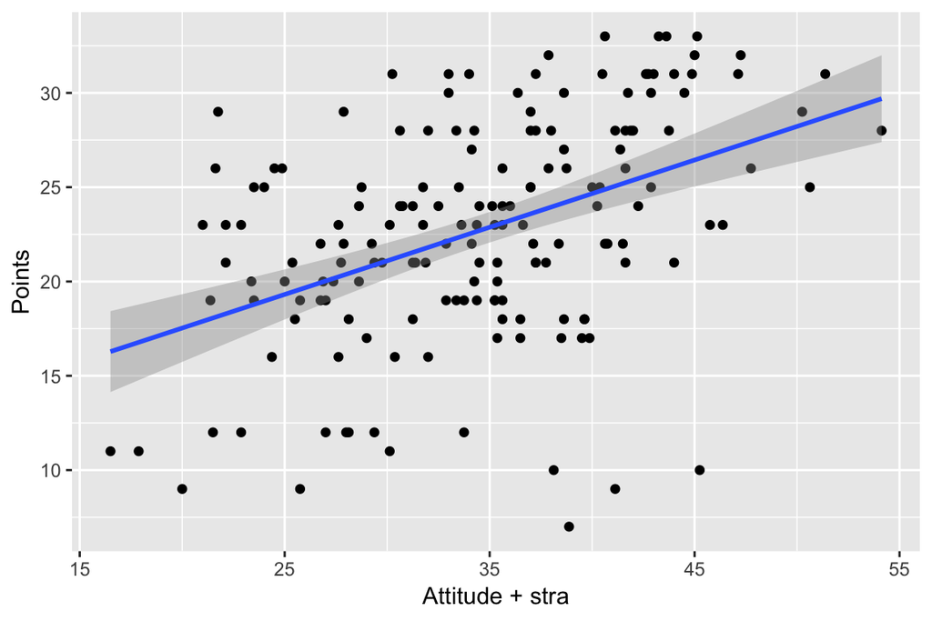

```r
qplot(Attitude+stra, Points, data = learning2014) + geom_smooth(method = "lm")
```

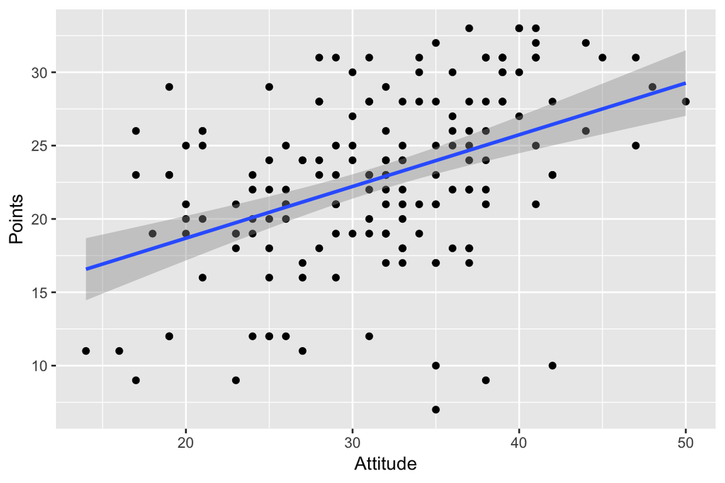

```r
qplot(Attitude, Points, data = learning2014) + geom_smooth(method = "lm")
```

Validation of the data for the model: Below the regression models LM2 and LM3 are subjected to diagnostic plots.

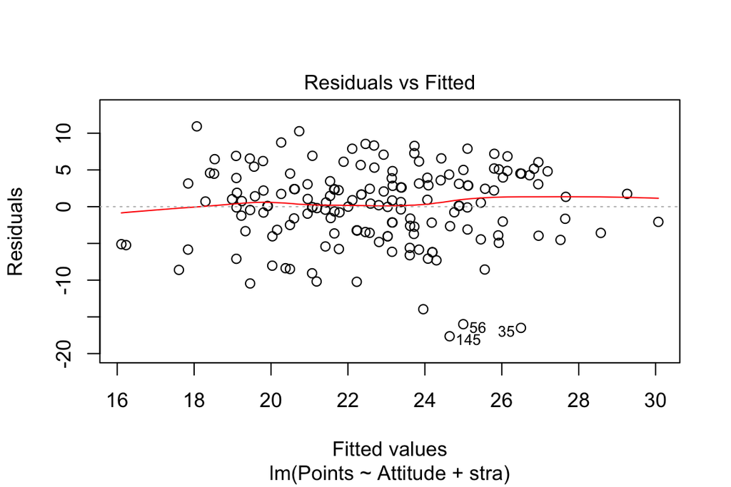

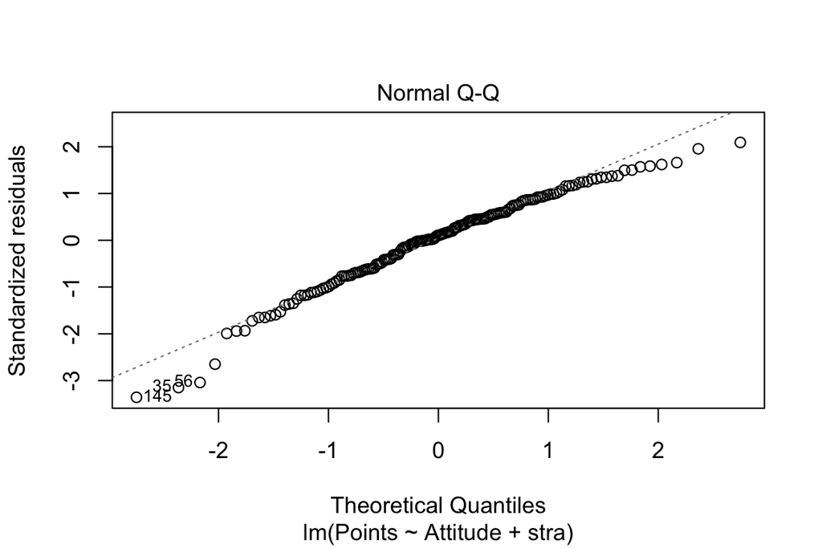

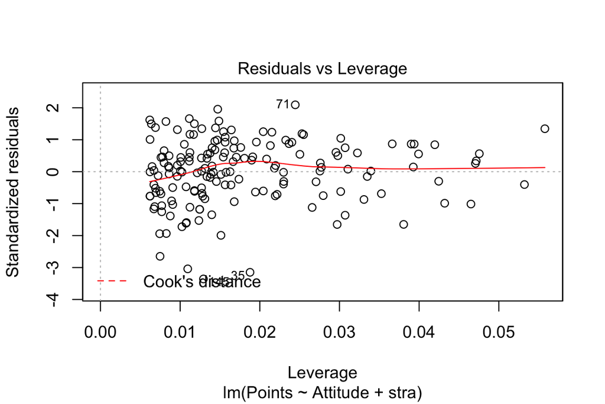

```r
plot(LM2, which = c(1,2,5))
```

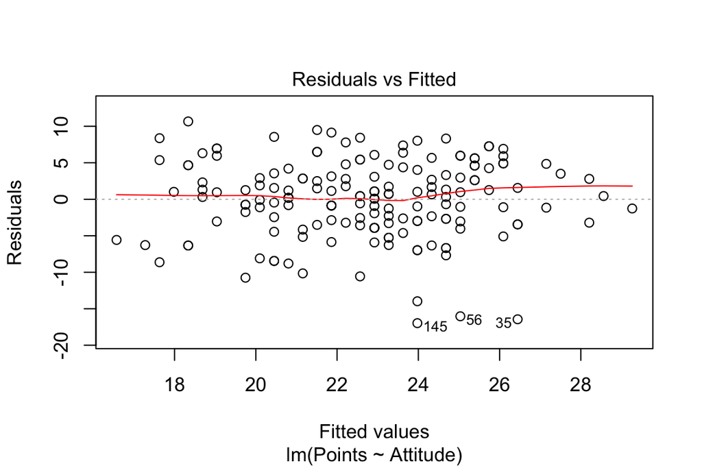

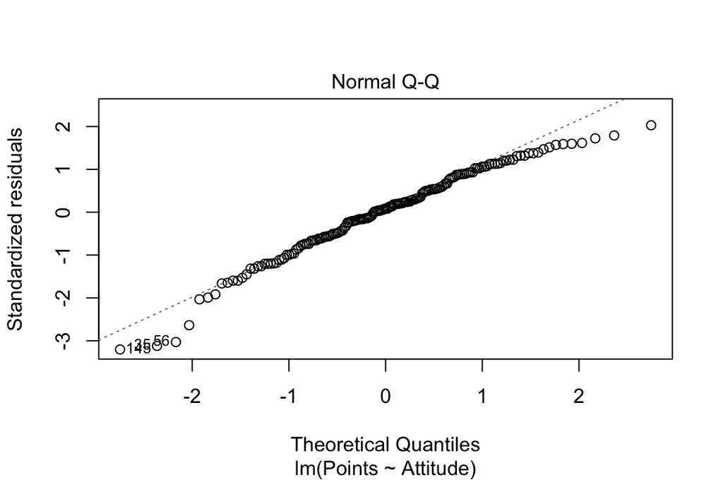

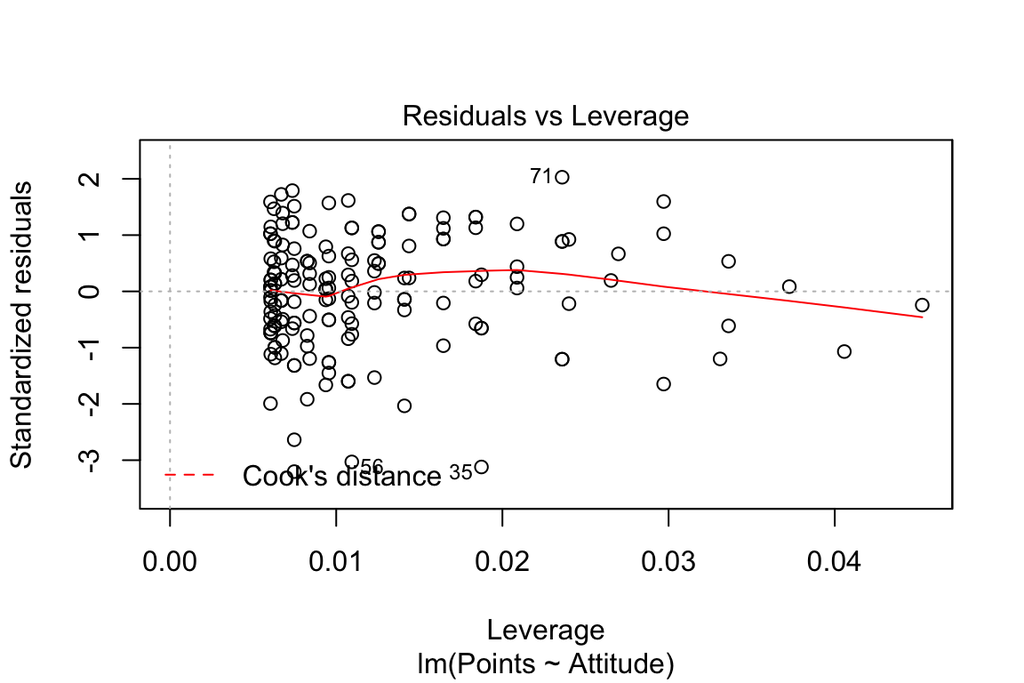

```r
plot(LM3, which= c(1,2,5))
```

The diagnostic test are used to see how well our data fits the model. 1. Residual vs fitted values: Shows the residuals variance of error. In this case quite a good fit, we see no pattern in in the scatter plot. 2. Normal Q-Q plot: shows if residuals from our model are normally distribiuted, witch is an assumtion for the model. In this case some deviation from normal can be seen at extremes, but I interpret that data fits model well enough. 3.Residuals vs leverage: Helps us find influencial subjects that could have an impact on the regression line (=not all outliers are influencial i.e determine the regression line). Here no cases are seen outside cooks distance, i.e. there are not influencial extremes in the data.

The interpretation is that the data fits the regression model (both the multiple (2 variables) and simple regression model) and that the model is valiated for the data. ***

# Logisitic regression and cross validationn

This exercise is based on a data set about student achievement in secondary education in two Portuguese schools. Data includes student grades,demographic, social and school related features and it was collected by using school reports and questionnaires. The data “alc” is a subset of this data, with alcohol use on weekdays and weekends combined by averaging and high use defined >2 (scale: 1 = very low to 5 very high). Links to [original dataset](https://archive.ics.uci.edu/ml/datasets/Student+Performance) and [publication](http://www3.dsi.uminho.pt/pcortez/student.pdf).

### *Exploring the data*

Readning the wrangled data from local disk.

```r
alc<-read.table("/Users/Annina/Documents/GitHub/IODS-project/Data/alc.txt",sep=";")
```

Next lets explore the data:

```r
dim(alc)
```

```
## [1] 382  35
```

```r
colnames(alc)
```

```
##  [1] "school"     "sex"        "age"        "address"    "famsize"
##  [6] "Pstatus"    "Medu"       "Fedu"       "Mjob"       "Fjob"
## [11] "reason"     "nursery"    "internet"   "guardian"   "traveltime"
## [16] "studytime"  "failures"   "schoolsup"  "famsup"     "paid"
## [21] "activities" "higher"     "romantic"   "famrel"     "freetime"
## [26] "goout"      "Dalc"       "Walc"       "health"     "absences"
## [31] "G1"         "G2"         "G3"         "alc_use"    "high_use"
```

The data set is composed of 35 variables and 382 observations(ie.382 students)

```r
summary(alc$high_use) # = alc_use >2 = TRUE
```

```
##    Mode   FALSE    TRUE
## logical     268     114
```

The response variable of interest is the binary variable “high_use” (TRUE/FALSE) correspoinding to alcohol use >2 on a scale from 1-5.

My hypotesis is that high alcohol use is correlated to the variables; “goout”,“sex” and “abscences” and that these could be used in a model for predicting high use. My hypothesis is that male students drink more than female students. People who go out more drink more alcohol and that people that have more abscences from school drink more alcohol.

Lets look at the chosen variables:

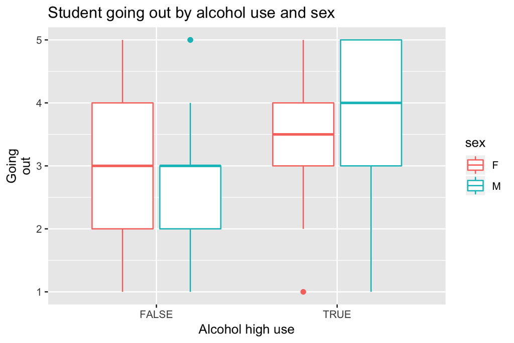

```r
p1 <- ggplot(alc, aes(x=high_use, y = goout, col=sex))+geom_boxplot()+ylab("Going
out")+xlab("Alcohol high use")+ggtitle("Student going out by alcohol use and sex")
p1
```

In this boxplot we can se that male students go out more than female and that more going out seems positively related to high alcohol use.

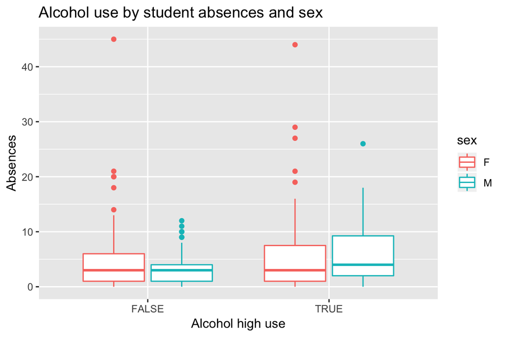

```r
p2 <- ggplot(alc, aes(high_use, absences, col=sex))+ylab("Absences")+xlab("Alcohol high use")+geom_boxplot()+ggtitle("Alcohol use by student absences and sex")

p2 #numeric 0-93 days
```

In this boxplot it looks like the students having high alcohol use have somewhat more absences.

```r
table(alc$high_use,alc$sex)
```

```
##
##           F   M
##   FALSE 156 112
##   TRUE   42  72
```

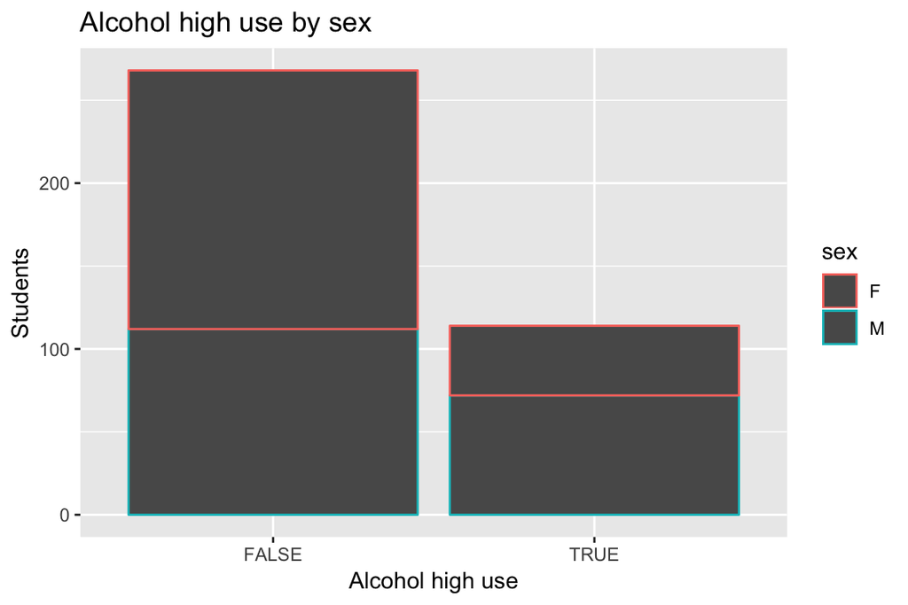

```r
p3 <- ggplot(alc, aes(high_use, col=sex))+geom_bar()+ylab(
"Students")+xlab("Alcohol high use")+ggtitle("Alcohol high use by sex")
p3
```

In this barplot we se that more men than women are in the high use group.